# WeRateDogs

it is a Twitter account that rates people's dogs with a humorous comment about the dog. These ratings almost always have a denominator of 10. The numerators, though? Almost always greater than 10. 11/10, 12/10, 13/10, etc. Why? Because "they're good dogs Brent." WeRateDogs has over 4 million followers and has received international media coverage.

if you are interested in dogs you will find this very enjoyable as it will present very nice information and pictures about various dogs types.

# people interactions on tweets over time

- Here we can see that favourite count is increasing over time and retweets facourite counts reached very high values .

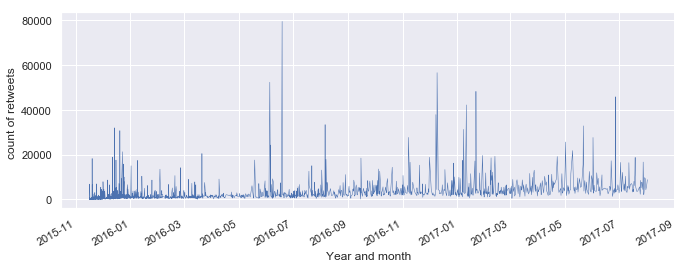

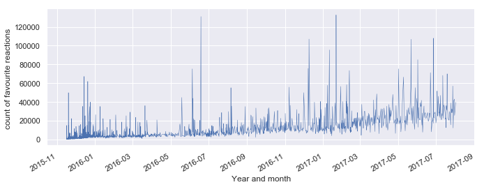

# here is a picture of the dog who has the most favourite raction count on the data

[figure not shown]

# most common dog names:

- charlie is the most common dog name and lucy ,cooper and oliver come in the second place

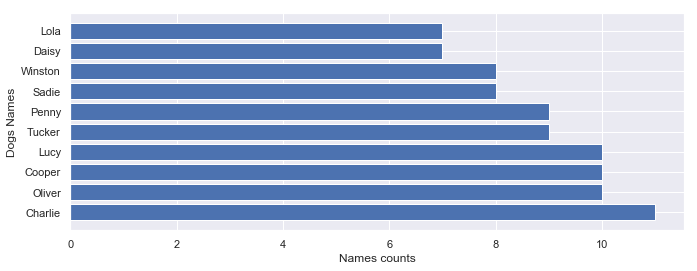

# most common dog breeds :

- now we can see that golden retriver and Labrador Retriver is the most common dog breeds

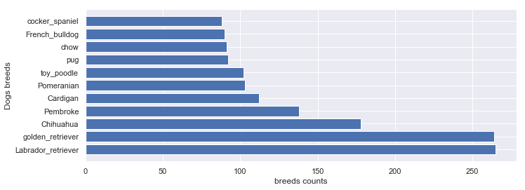